# Reproducible Research Peer Assessment1

huangli

2015-06-13

## Introduction

This research makes use of data from a personal activity monitoring device. This device collects data at 5 minute intervals through out the day. The data consists of two months of data from an anonymous individual collected during the months of October and November, 2012 and include the number of steps taken in 5 minute intervals each day.

This research will answer a few questions about the activity data below.

## Data

The data for this research can be downloaded from the course web site: Dataset: [Activity monitoring data](https://d396qusza40orc.cloudfront.net/repdata%2Fdata%2Factivity.zip) [52K]

The variables included in this dataset are:

- steps: Number of steps taking in a 5-minute interval (missing values are coded as NA)
- date: The date on which the measurement was taken in YYYY-MM-DD format
- interval: Identifier for the 5-minute interval in which measurement was taken The dataset is stored in a comma-separated-value (CSV) file and there are a total of 17,568 observations in this dataset.

we may take a snippet of the data

```r
df <- read.csv("activity.csv", header=T, stringsAsFactors=F)
head(df)
```

```
##   steps       date interval
## 1    NA 2012-10-01        0
## 2    NA 2012-10-01        5
## 3    NA 2012-10-01       10
## 4    NA 2012-10-01       15
## 5    NA 2012-10-01       20
## 6    NA 2012-10-01       25
```

## Questions

### What is mean total number of steps taken per day?

#### 1. Make a histogram of the total number of steps taken each day

Load library dplyr to group by the data by date and then sum the steps, the ggplot2 library to draw the histogram.

```r
library(dplyr)
```

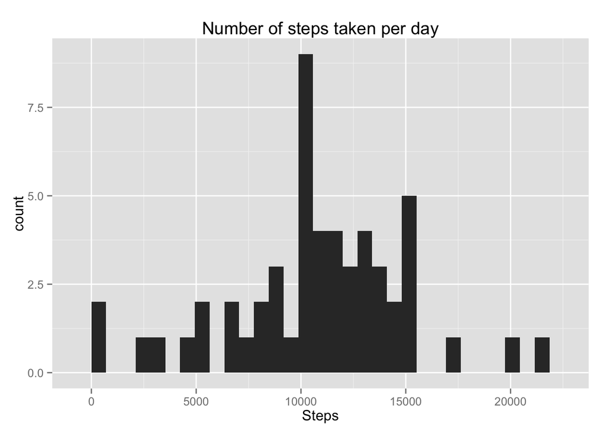

```r
# load the data and sum by date
df <- read.csv("activity.csv", header=T, stringsAsFactors=F)
by_day <- group_by(df, date)
by_day <- summarize(by_day, steps = sum(steps))
by_day <- by_day[complete.cases(by_day),]

# plot
library(ggplot2)
qplot(by_day$steps,
        geom="histogram",
        main = "Number of steps taken per day",
        xlab="Steps")
```

#### 2. Calculate and report the mean and median total number of steps taken per day

**mean**

I will remove the na values to get a sum of steps then divide by all the days in the dataset, the mean value is 9354.23.

```r
df <- read.csv("activity.csv", header=T, stringsAsFactors=F)
sum(df$steps, na.rm=T)/length(unique(df$date))
```

```
## [1] 9354.23
```

**median**

The median value is 10765.

```r
df <- read.csv("activity.csv", header=T, stringsAsFactors=F)
by_date <- group_by(df, date)
by_day <- summarize(by_date, steps=sum(steps))
median(by_day$'steps', na.rm=T)
```

```
## [1] 10765
```

### What is the average daily activity pattern?

#### 1. Make a time series plot (i.e. type = “l”) of the 5-minute interval (x-axis) and the average number of steps taken, averaged across all days (y-axis)

avg steps = sum all the steps by interval / num of unique days in dataset

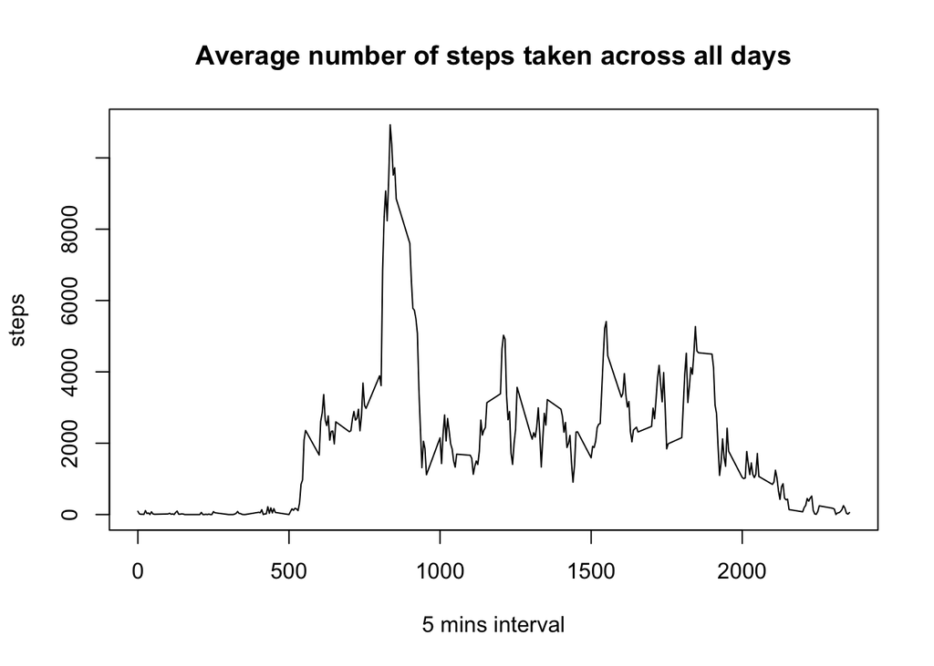

```r
library(dplyr)
df <- read.csv("activity.csv", header=T, stringsAsFactors=F)
df_rm_na <- df[complete.cases(df),]
by_interval <- group_by(df_rm_na,interval)
num_of_days <- length(unique(df$date))
by_interval <- summarise(by_interval, steps=sum(steps))
by_interval <- mutate(by_interval, avg = steps / num_of_days)

# plot
with(by_interval,
        plot(x=interval,
              y=steps,
              type="l",
              xlab="5 mins interval",
              main="Average number of steps taken across all days"))
```

#### 2. Which 5-minute interval, on average across all the days in the dataset, contains the maximum number of steps?

The answer is inteval 835. The by_interval variable is the one used in the previous question, here we use which.max to get row index

```r
df <- read.csv("activity.csv", header=T, stringsAsFactors=F)
by_interval[which.max(by_interval$steps),1]
```

```
## Source: local data frame [1 x 1]
##
##   interval
## 1      835
```

### Imputing missing values

#### 1. Calculate and report the total number of missing values in the dataset (i.e. the total number of rows with NAs)

The total missing values is 2304.

```r
df <- read.csv("activity.csv", header=T, stringsAsFactors=F)
sum(is.na(df))
```

```
## [1] 2304
```

#### 2. Devise a strategy for filling in all of the missing values in the dataset. The strategy does not need to be sophisticated. For example, you could use the mean/median for that day, or the mean for that 5-minute interval, etc.

My strategy is replace all NA with mean for all dataset group by interval, the by_interval variable is the one used in previous quesion(daily activity pattern), which is a sum of steps group by interval.

```r
df <- read.csv("activity.csv", header=T, stringsAsFactors=F)
df_no_na <- df
for(i in 1:nrow(df_no_na)){
    if(is.na(df_no_na[i, 1])){
    #replace all the na with average 5-minute interval across all day
        df_no_na[i,1] <- subset(by_interval,
                                interval == df_no_na[i,3],
                                select = avg)
    }
}
```

#### 3. Create a new dataset that is equal to the original dataset but with the missing data filled in.

The new dataset is is the previous question df_no_na, the snippet of the data is below.

```r
head(df_no_na)
```

```
##        steps       date interval
## 1 1.49180328 2012-10-01        0
## 2 0.29508197 2012-10-01        5
## 3 0.11475410 2012-10-01       10
## 4 0.13114754 2012-10-01       15
## 5 0.06557377 2012-10-01       20
## 6 1.81967213 2012-10-01       25
```

#### 4. Make a histogram of the total number of steps taken each day and Calculate and report the mean and median total number of steps taken per day. Do these values differ from the estimates from the first part of the assignment? What is the impact of imputing missing data on the estimates of the total daily number of steps?

They are different from the estimates from the first part of the assignment.

Impact: average value becomes bigger,median becomes smaller.

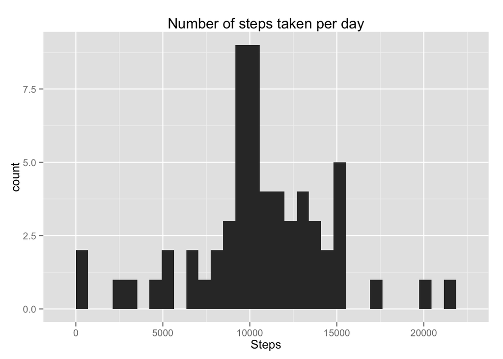

```r
df <- read.csv("activity.csv", header=T, stringsAsFactors=F)
# total number of steps taken each day
by_date_no_na <- group_by(df_no_na, date)
by_date_no_na <- summarize(by_date_no_na, steps = sum(steps))
library(ggplot2)
qplot(by_date_no_na$steps,
      geom="histogram",
      main = "Number of steps taken per day",
      xlab="Steps")
```

```r
# mean steps
mean(by_date_no_na$steps)
```

```
## [1] 10581.01
```

```r
# median stpes
median(by_date_no_na$steps)
```

```
## [1] 10395
```

### Are there differences in activity patterns between weekdays and weekends?

#### 1. Create a new factor variable in the dataset with two levels – “weekday” and “weekend” indicating whether a given date is a weekday or weekend day.

df_no_na is the variable used in previous question, all the NA are replaced with mean of interval acrossed all days. the weekdays(df_no_na$date) %in% weekdays1 returns true or false, when add 1 it becomes 1(false+1L) or 2(true+1L).

```r
df_no_na$date <- as.Date(df_no_na$date)
weekdays1 <- c('Monday', 'Tuesday', 'Wednesday', 'Thursday', 'Friday')
df_no_na$wDay <-  factor((weekdays(df_no_na$date) %in% weekdays1)+1L,
                    levels=1:2,
                    labels=c('weekend', 'weekday'))
```

```r
library(reshape2)
```

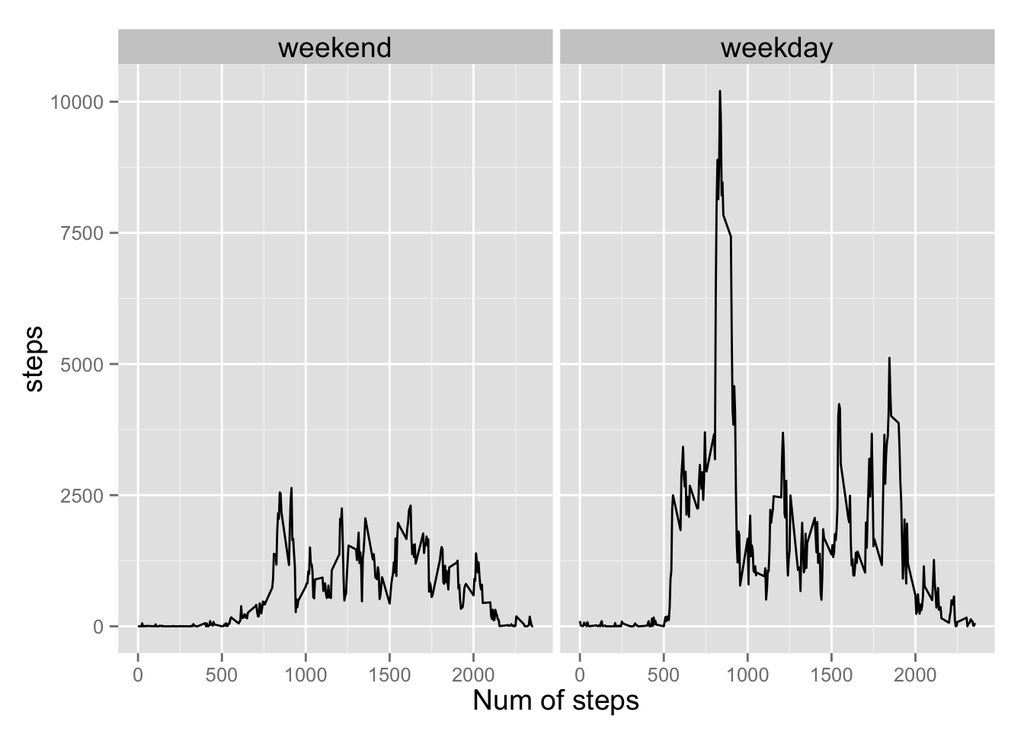

```r
library(ggplot2)

df_by_interval_replace_na <- group_by(df_no_na, interval,wDay)
df_by_interval_replace_na <- summarize(df_by_interval_replace_na, steps=sum(steps))

sp <- ggplot(df_by_interval_replace_na,
                aes(x=interval, y=steps))

# make the title bigger and create a facet by factor wDay(weekday or weekend)
sp + facet_grid(. ~ wDay) + theme(strip.text.x=element_text(size=14), title=element_text(size=14)) + geom_line() + xlab("Num of steps")
```